# Homework 6: Incomplete

Connecticut Real Estate Sales Data

Joseph Farrell  
2022-03-30

**Load Libraries**

```r
library(readr)
library(tidyverse)
library(dplyr)
library(mosaic)
library(ggplot2)
library(lubridate)
library(xts)
library(formattable)
library(forecast)
library(kableExtra)
```

## Read in Data

**Read in data**

```r
connecticut <- read_csv("/Users/nelsonfarrell/Downloads/Real_Estate_Sales_2001-2019_GL.csv")
county_town <- read_csv(("/Users/nelsonfarrell/Documents/501 Stats/Connecticut County:Towns.csv"))
county_town <- county_town %>%
  select("subregion", "town")
```

- Here I am reading in two data sets:
  - Connecticut, which has Connecticut real estate sales data
  - county_town, which has a list of Connecticut counties and the towns that are in each county.

## Data Wrangling

**Rename “Town” variable “town” to join datasets**

```r
connecticut <- rename(connecticut, "town" = "Town")
```

- Here I am changing the name of the “Town” variable in the Connecticut data set so it will match the “town” variable in the county_town data set.

**Join datasets**

```r
connecticut <-
  left_join(connecticut, county_town, by = "town")
```

- Here am joining the data sets, this will be useful when grouping in the analysis.

**Remove columns “Serial number”, “Non Use Code”, “Assessor Remarks”, “Sales Ratio”, “Property Type”, “Location”, and “OPM Remarks”**

```r
connecticut <- select(connecticut,
                      "List Year",
                      "Date Recorded",
                      "town",
                      "Assessed Value",
                      "Sale Amount",
                      "Residential Type",
                      "subregion")
```

- These removed columns do not appear to be essential to the analysis

**Remove NAs from “Residential Type”**

```r
connecticut <- connecticut %>%
  na.omit(`Residential Type`)
connecticut %>%
  count(`Residential Type`) %>%
  rename("Number of Properties Sold" = "n") %>%
  formattable(align = c("l","r"), list(`Number of Properties Sold` = color_bar("lightblue")))
```

| Residential Type | Number of Properties Sold |
| --- | --- |
| Condo | 105420 |
| Four Family | 2150 |
| Single Family | 401611 |
| Three Family | 12586 |
| Two Family | 26408 |

- The NAs removed here are simply nonresidential properties, which will not be part of the analysis.
- I am also looking how many observations there are for each `residential_type`.
  - We can see that majority of the observations are “Single Family” and “Condo.”
  - The least represented group is “Four Family” with only 2150 observations across all towns in Connecticut over the ~15 years of the data.

**Rename columns without spaces and for clarity**

```r
connecticut <- rename(connecticut,
                      "list_year" = "List Year",
                      "sale_date" = "Date Recorded",
                      "assessed_price" = "Assessed Value",
                      "sale_price" = "Sale Amount",
                      "residential_type" = "Residential Type",
                      "county" = "subregion")
```

**Convert “sale_date” from character to date and create new column “sale_year”**

```r
connecticut$sale_date <- as_date(connecticut$sale_date,
                                 format = "%m/%d/%Y")
connecticut <- connecticut %>%
  mutate(sale_year = year(sale_date))
```

**Remove all observations prior to 2007**

```r
connecticut <- connecticut %>%
  filter(sale_year > 2007)
```

**Remove top and bottom 2.5% of “sale_price”**

```r
connecticut <- connecticut %>%
  filter(sale_price < quantile(connecticut$sale_price, .975) &
           sale_price > quantile(connecticut$sale_price, .025))
```

**Create a line graph overall mean sale price of residential properties in Connecticut**

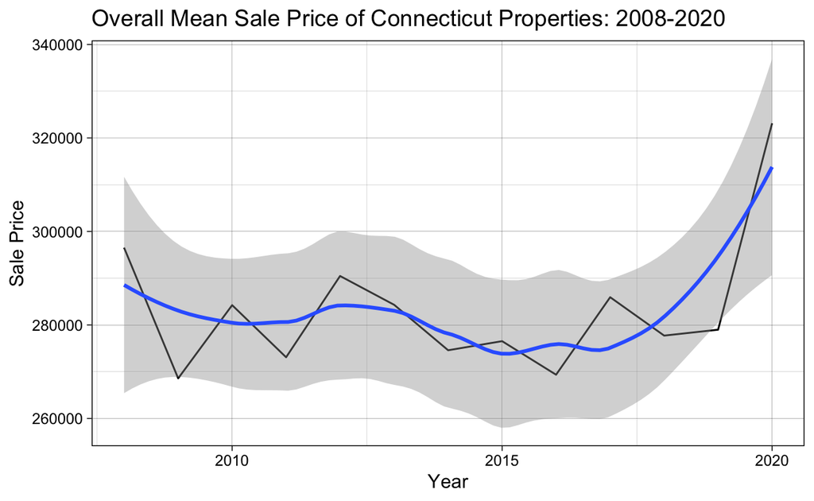

```r
connecticut %>%
  group_by(year = lubridate::floor_date(sale_date, "year")) %>%
  summarize(mean_year = mean(sale_price)) %>%
  ggplot(aes(x = year, y = mean_year)) +
  geom_line(aes()) +
  geom_smooth() +
  ggtitle("Overall Mean Sale Price of Connecticut Properties: 2008-2020") +
  ylab("Sale Price") +
  xlab("Year") +
  theme_linedraw()
```

- Here we can see that the mean sale price of properties in Connecticut appears to be increasing.
- This graphic displays all the property types combined which may not generate the most reliable results. For the rest of the analysis, like property types will be compared.

**Create scatterplot of “mean_monthly_sale_price” grouped by “residential_type”**

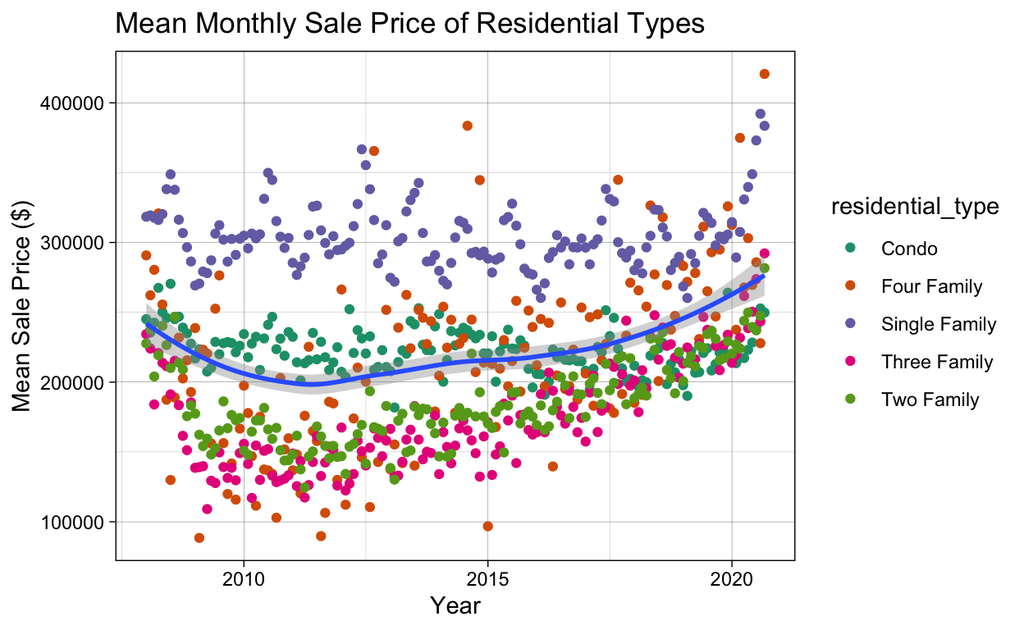

```r
options(scipen = 999) # remove scientific notation
connecticut %>%
  group_by(residential_type, month = lubridate::floor_date(sale_date, "month")) %>%
  summarize(mean_monthy_sale_price = mean(sale_price)) %>%
  ggplot(aes(x = month, y = mean_monthy_sale_price)) +
  geom_point((aes(color = residential_type))) +
  geom_smooth() +
  ggtitle("Mean Monthly Sale Price of Residential Types") +
  ylab("Mean Sale Price ($)") +
  xlab("Year") +
  theme_linedraw() +
  scale_color_brewer(palette = "Dark2")
```

- This graphic displays the mean monthly sale price of all properties in Connecticut grouped by the type of property.
- Interestingly, Single Family homes have the highest mean sale price.
- We can get a closer look below.

**Scatterplot of yearly mean sale price for each “residential_type” with confidence intervals and regression line**

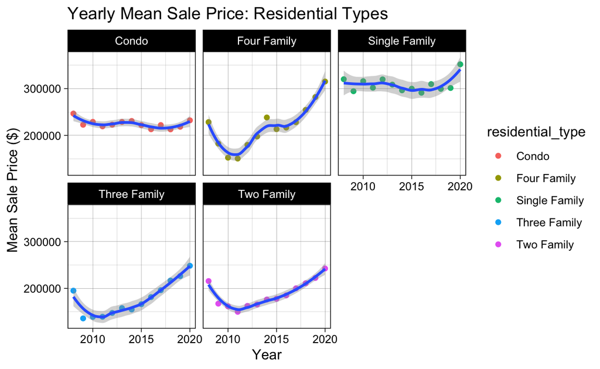

```r
options(scipen = 999) # remove scientific notation
connecticut %>%
  group_by(residential_type, year = lubridate::floor_date(sale_date, "year")) %>%
  summarize(mean_year_type = mean(sale_price)) %>%
  ggplot(aes(x = year, y = mean_year_type, group = residential_type)) +
  geom_point((aes(color = residential_type))) +
  geom_smooth() +
  ggtitle("Yearly Mean Sale Price: Residential Types") +
  ylab("Mean Sale Price ($)") +
  xlab("Year") +
  theme_linedraw() +
  facet_wrap(vars(residential_type))
```

- This graphic displays the behavior of the mean sale price of the different “residential_types”.
- The graphic shows that multi-unit properties appear to be increasing in value faster than single family properties (i.e. condo and single family), overall.
- Four family properties appear to be increasing the fastest, but as displayed earlier, four family properties represent the smallest data set, with only 2150 total observations, which could potentially make the data less reliable. This could also explain the apparent volatility in the price of Four Family properties.

## Map Visualization

**Read in map data**

```r
con_map <- map_data("county",
         "connecticut")
```

- This dataset contains latitude and longitude data that can be used to make a map visualization.

**Rename “subregion” “county” to join “con_map” with “connecticut”**

```r
con_map <- rename(con_map,
                  "county" = "subregion")
```

- The “subregion” in the “con_map” data set is Connecticut counties so I will rename the variable so I can join it with the sales data.

**Create object `map_vis`: grouping by county and creating a “county_mean” column**

```r
map_vis <- connecticut %>%
  group_by(county) %>%
  summarize(county_mean = mean(sale_price))
```

- This object contains the mean sale price of each county in Connecticut and will be joined the map data to display the mean sale price on a map.

**Join `mapping` object with `con_map` data**

```r
map_vis <- inner_join(map_vis, con_map, by = "county")
```

- This object will be used to create a map visualization displaying county mean sale price.

**Create object to use when labeling the counties on the map**

```r
county_names <- aggregate(cbind(long, lat) ~ county, data=map_vis,
                    FUN=function(x)mean(range(x)))
```

- This creates an object that will center the name of the county inside that county on the map visualization.

**Create map of Connecticut counties displaying the mean sale price of residential properties**

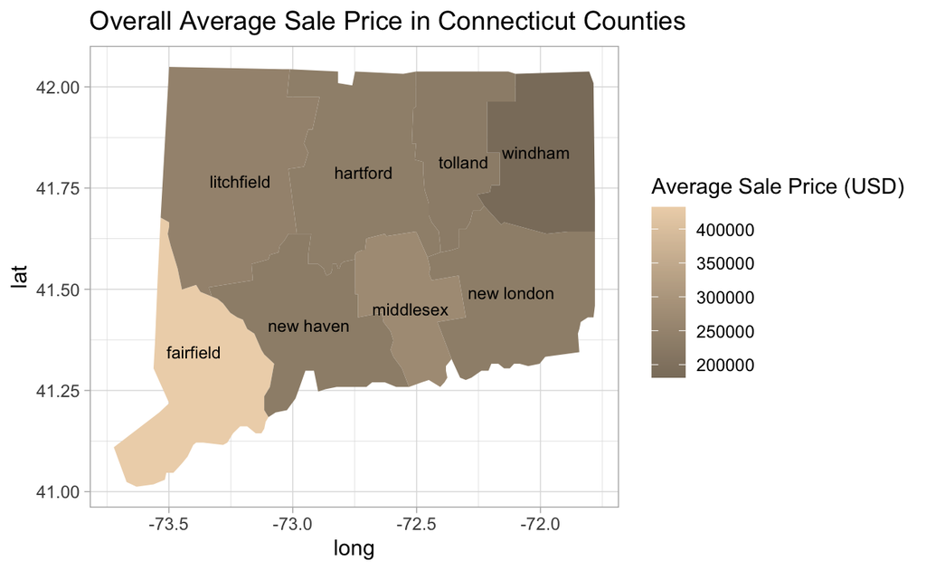

```r
ggplot(map_vis, aes(x = long, y = lat)) +
  geom_polygon(aes(fill = county_mean, group = county)) +
  geom_text(data = county_names, aes(long, lat, label = county), size =3) +
  scale_fill_gradient(low = "bisque4", high = "bisque2", name = "Average Sale Price (USD)") +
  ggtitle("Overall Average Sale Price in Connecticut Counties") +
  theme_light()
```

- Here we can get a visualization of where in Connecticut (grouped by county) property values are the highest.
- Not surprisingly, the area closest to New York City appears to have the highest property value.

## Change in mean “sale_price” of “Single Family” properties

- Here I am going to isolate the mean sale price of single family properties in Connecticut counties so I can find the difference between the mean in 2008 and 2020.

**Create of object of mean `sale price` of `Single Family` properties for each county in 2008**

```r
msf_2008 <- connecticut %>%
  group_by(county,
           residential_type,
           sale_year) %>%
  select(county,
         residential_type,
         sale_year,
         sale_price) %>%
  summarize(mean_3 = mean(sale_price)) %>%
  filter(sale_year == "2008" &
         residential_type == "Single Family")
```

```r
msf_2020 <- connecticut %>%
  group_by(county,
           residential_type,
           sale_year) %>%
  select(sale_year,
         residential_type,
         sale_price,
         county) %>%
  summarize(mean_3 = mean(sale_price)) %>%
  filter(sale_year == "2020" &
         residential_type == "Single Family")
```

**Join `mean_2008` and `mean_2020` and create new column `delta_mean` and `c_mean`**

```r
msf_08_20 <- msf_2008 %>%
  left_join(msf_2020, by = "county") %>%
  mutate(delta_mean = mean_3.y - mean_3.x) %>%
  mutate(c_mean = (mean_3.y - mean_3.x)/mean_3.x) %>%
  mutate(c_mean = c_mean * 100) %>%
  mutate(across(contains("mean"), round, 2)) %>%
  rename("mean_08" = "mean_3.x",
         "mean_20" = "mean_3.y") %>%
  select("county",
         "mean_08",
         "mean_20",
         "delta_mean",
         "c_mean")
```

- The “delta_mean” column here is obtained by subtracting the mean of “Single Family” properties sold in 2008 from the mean of “Single Family” properties in 2020.
- The “c_mean” column is obtained by taking “delta_mean” and dividing by the mean of “Single Family” properties sold in 2008.

**Create a table of the change in mean sale price of “Single Family” properties in the eight Connecticut counties**

```r
msf_08_20 %>%
  rename("County" = "county",
         "Mean 2008" = "mean_08",
         "Mean 2020" = "mean_20",
         "Change in Mean ($)" = "delta_mean",
         "Change in Mean (%)" = "c_mean") %>%
  formattable(list(`Mean 2020` = FALSE,
                   `Mean 2008` = FALSE,
                   `Change in Mean (%)` = formatter("span",
                 style = ~ style(color = ifelse(`Change in Mean (%)` < 0,
                                                "firebrick",
                                                "forestgreen")),
                 ~ icontext(sapply(`Change in Mean (%)`,
                                   function(x) if (x < 0) "arrow-down" else if (x > 0) "arrow-up"),
                            `Change in Mean (%)`))))
```

| County | Change in Mean ($) | Change in Mean (%) |
| --- | --- | --- |
| fairfield | 63048.12 | 12.56 |
| hartford | 13893.09 | 5.21 |
| litchfield | 60529.46 | 20.61 |
| middlesex | -13165.68 | -3.97 |
| new haven | 110.93 | 0.04 |
| new london | 1967.19 | 0.72 |
| tolland | -6082.70 | -2.29 |
| windham | 24476.58 | 11.89 |

**Create Bargraph of the change in mean sale price from 2008 to 2020**

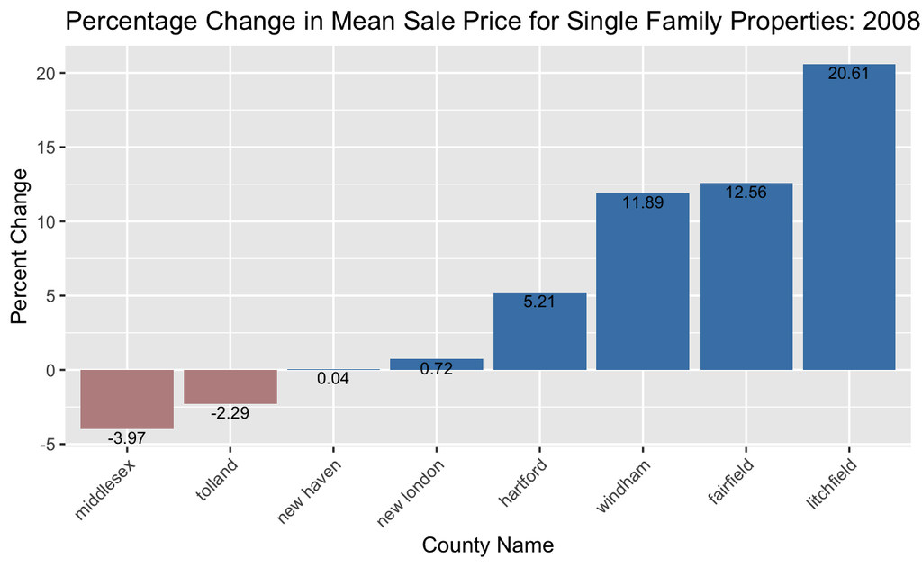

```r
msf_08_20 %>%
  mutate(Color = ifelse(c_mean < 0, "rosybrown","steelblue")) %>%
  ggplot(aes(x = reorder(county, +c_mean),
             y = c_mean,
             fill = Color)) +
  geom_col()+
  geom_text(aes(label = c_mean,
                vjust = 1.2),
                size = 3) +
  labs(title = "Percentage Change in Mean Sale Price for Single Family Properties: 2008 to 2020",
                x = "County Name",
                y = "Percent Change") +
  theme(axis.text.x = element_text(angle = 45,
                                   hjust = 1)) +
  scale_fill_identity(guide = "none")
```

- The above two graphics display the change in mean “sale price” of single family properties from 2008 to 2020 in the 8 Connecticut counties.
- These graphics help narrow down our analysis and target our search to specific areas.

**Create line graph of mean sale price of single family properties in each county from 2008 to 2020**

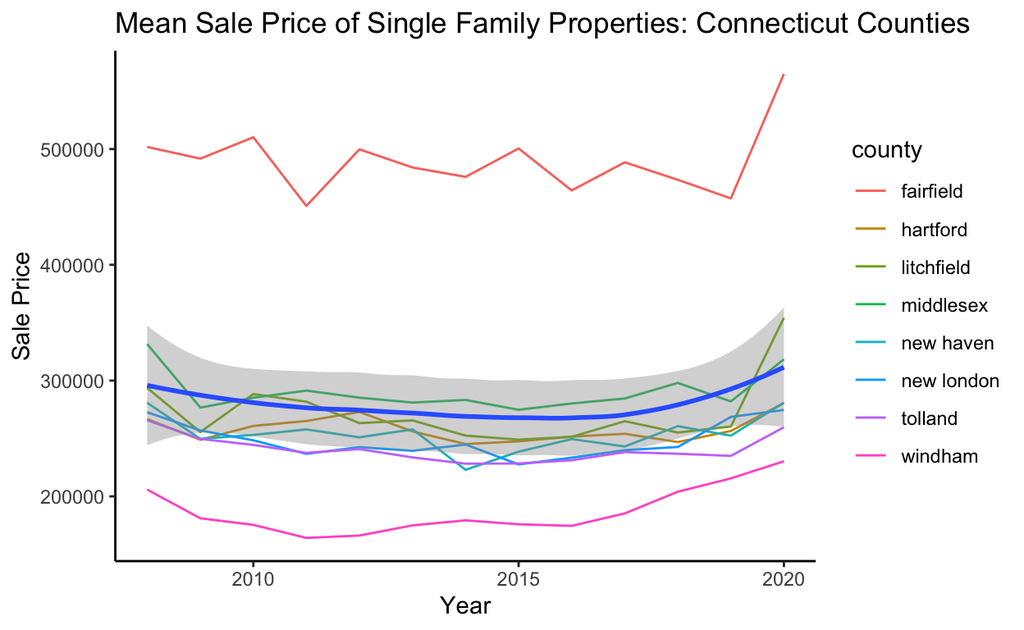

```r
connecticut %>%
  group_by(county, residential_type, year = lubridate::floor_date(sale_date, "year")) %>%
  summarize(county_mean = mean(sale_price)) %>%
  filter(residential_type == "Single Family") %>%
  ggplot(aes(x = year, y = county_mean)) +
  geom_line(aes(color = county)) +
  ggtitle("Mean Sale Price of Single Family Properties: Connecticut Counties") +
  geom_smooth() +
  ylab("Sale Price") +
  xlab("Year") +
  theme_classic()
```

**Create line graph of the mean sale price of single family properties in different counties**

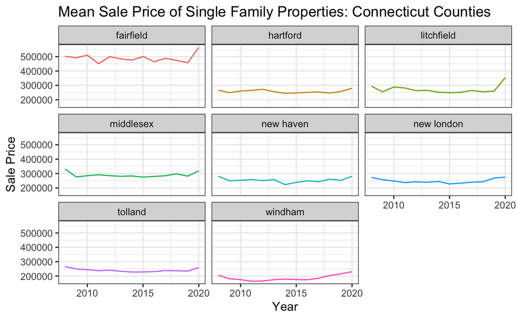

```r
connecticut %>%
  group_by(county,
           residential_type,
           year = lubridate::floor_date(sale_date, "year")) %>%
  summarize(mean_year = mean(sale_price)) %>%
  filter(residential_type == "Single Family") %>%
  ggplot(aes(x = year,
             y = mean_year)) +
  geom_line(aes(color = county)) +
  ggtitle("Mean Sale Price of Single Family Properties: Connecticut Counties") +
  ylab("Sale Price") +
  xlab("Year") +
  theme_bw() +
  facet_wrap(vars(county)) +
  guides(color = "none")
```

- These graphics display the behavior of the mean sale price of single family properties in the eight Connecticut counties over the ~15 years of the data.
- We can see clearly that property values are the highest in Fairfield County, but we can also see that property values are increasing in a number of Connecticut counties, this increase appears most pronounced in Fairfield and Litchfield.
- This further helps us refine our search.

## Diving deeper into Litchfield County Sale Prices

**Create graphic of mean yearly sale price for just Litchfield County, group by property type**

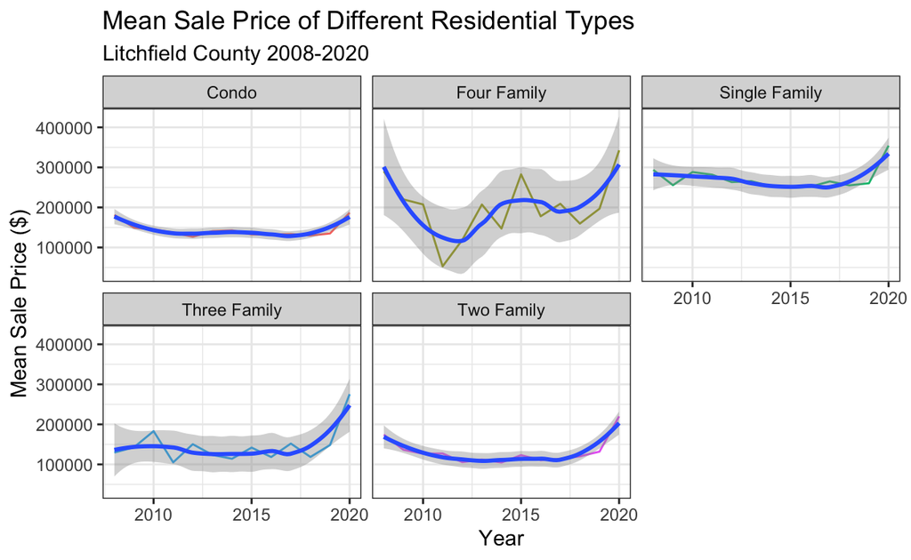

```r
connecticut %>%
  filter(county == "litchfield") %>%
  group_by(residential_type,
           year = lubridate::floor_date(sale_date, "year")) %>%
  summarize(mean_litchfield = mean(sale_price)) %>%
  ggplot(aes(x = year,
             y = mean_litchfield)) +
  geom_line(aes(color = residential_type)) +
  geom_smooth() +
  theme_bw() +
  labs(title = "Mean Sale Price of Different Residential Types",
       subtitle = "Litchfield County 2008-2020",
       x = "Year",
       y = "Mean Sale Price ($)") +
  facet_wrap(vars(residential_type)) +
  guides(color = "none")
```

**Examine counts of residential type in Litchfield County**

```r
Litchfield <- connecticut %>%
  group_by(sale_year) %>%
  filter(county == "litchfield")
Litchfield %>%
  group_by(residential_type) %>%
  count(residential_type) %>%
  rename("Residential Type" = "residential_type",
         "Count: Properties Sold" = "n") %>%
  knitr::kable(caption = "Counts of Residential Types: Litchfield County") %>%
  kable_classic(full_width = T) %>%
  row_spec(2, background = "yellow") %>%
  row_spec(4, background = "yellow")
```

Table 1: Counts of Residential Types: Litchfield County

| Residential Type | Count: Properties Sold |
| --- | --- |
| Condo | 3611 |
| Four Family | 61 |
| Single Family | 22891 |
| Three Family | 327 |
| Two Family | 1177 |

- Here we can see a partial explanation for the volatility of the mean sale price of “Four Family” properties; with only 61 observations over 12 years it seems hard to rely on the data.
- We also see that “Three Family” is not well represented over the time period.

**Display counts of different residential types over the 12 years 2008-2020**

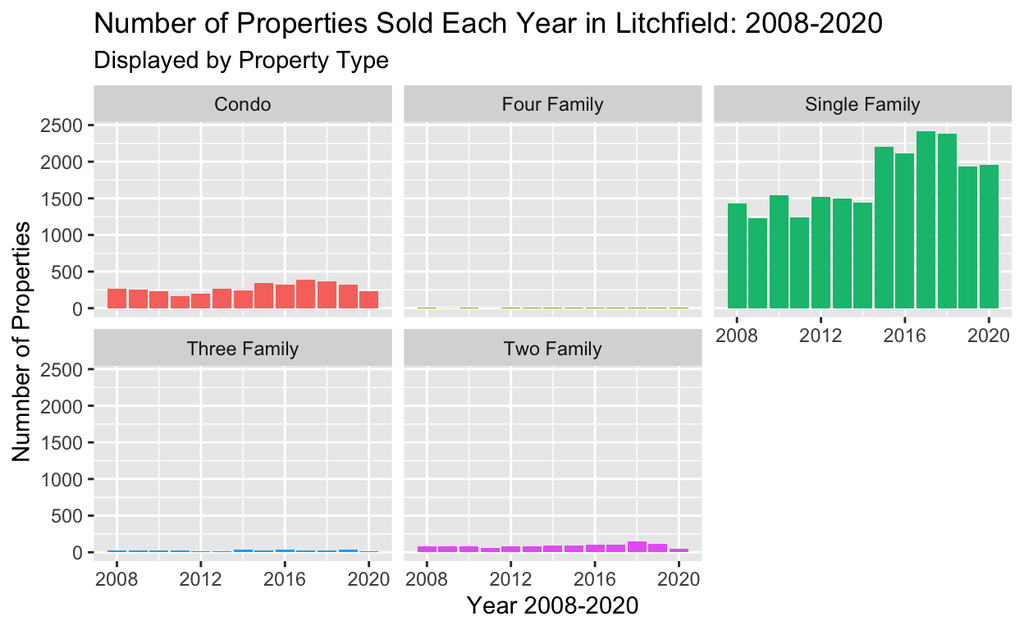

```r
Litchfield %>%
  group_by(sale_year, residential_type) %>%
  ggplot(aes(x = sale_year, fill = residential_type)) +
  geom_bar(aes(stat="identity")) +
  facet_wrap(vars(residential_type)) +
  labs(title = "Number of Properties Sold Each Year in Litchfield: 2008-2020",
       subtitle = "Displayed by Property Type",
       x = "Year 2008-2020",
       y = "Numnber of Properties") +
  theme(legend.position = "none")
```

- Here we can see clearly that our data set is primarily made up of “Sinlge Family” properties and “Condos”.

```r
Litchfield %>%
  filter(residential_type == "Four Family") %>%
  group_by(sale_year) %>%
  count(residential_type) %>%
  rename("Year" = "sale_year",
         "Residential Type" = "residential_type",
         "Total Sold" = "n") %>%
  knitr::kable(caption = "Counts of Four Family Properties Sold Each Year") %>%
  kable_classic(full_width = F, position = "left") %>%
  row_spec(4, background = "yellow")
```

Table 2: Counts of Four Family Properties Sold Each Year

| Year | Residential Type | Total Sold |
| --- | --- | --- |
| 2008 | Four Family | 3 |
| 2009 | Four Family | 2 |
| 2010 | Four Family | 4 |
| 2011 | Four Family | 1 |
| 2012 | Four Family | 3 |
| 2013 | Four Family | 3 |
| 2014 | Four Family | 5 |
| 2015 | Four Family | 3 |
| 2016 | Four Family | 5 |
| 2017 | Four Family | 4 |
| 2018 | Four Family | 10 |
| 2019 | Four Family | 10 |
| 2020 | Four Family | 8 |

- Here I have highlighted “2011” where there was only one “Four Family” property sold in the entirty of Litchfield County. While the counts do increase somewhat in the following years it will be impossible to look at individual towns with regards to “Four Family” properties.
- As a result of the limitations of the data examining different “residential_types” beyond the county level will not be revealing or possible.
- As we look at the towns in Litchfield County, we will only be looking a “Single Family” properties.

**Filter Litchfield County Object for only “Single Family” properties**

```r
Litchfield_SF <- Litchfield %>%
  filter(residential_type == "Single Family")
```

- As a result of the data being limited for “Residential Types” other than “Single Family” I will filter for “Single Family” before I look at the specific towns in Litchfield County.

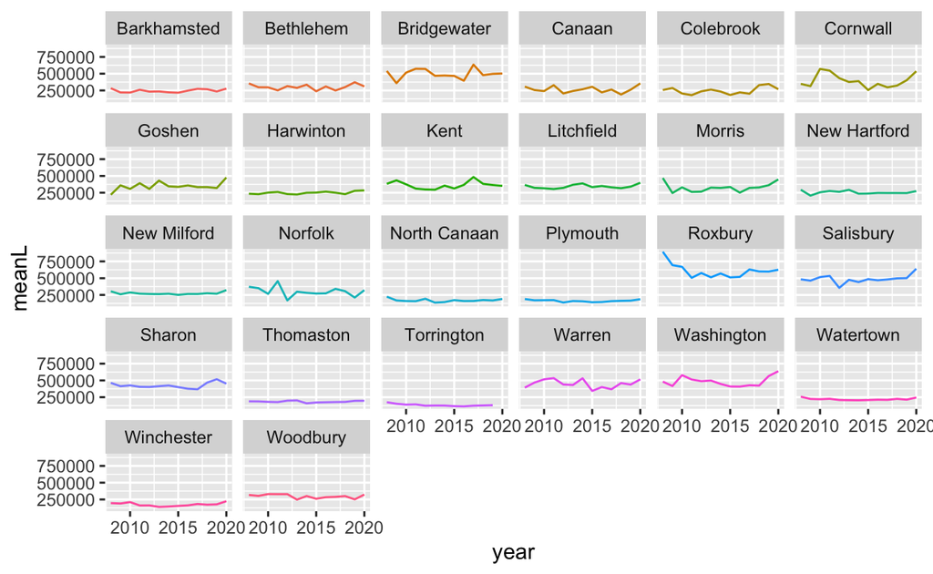

```r
Litchfield %>%
  group_by(town, year = lubridate::floor_date(sale_date, "year")) %>%
  summarize(meanL = mean(sale_price)) %>%
  ggplot(aes(x = year, y = meanL)) +
  geom_line(aes(color = town)) +
  facet_wrap(vars(town)) +
  guides(color = "none")
```

```r
L08 <- Litchfield_SF %>%
  group_by(town, sale_year) %>%
  summarise(mean_L08 = mean(sale_price)) %>%
  filter(sale_year == "2008")

L20 <- Litchfield_SF %>%
  group_by(town, sale_year) %>%
  summarise(mean_L20 = mean(sale_price)) %>%
  filter(sale_year == "2020")

L_combined <- L08 %>%
  left_join(L20, by = "town")

L_combined <- L_combined %>%
  mutate(L_delta_mean = mean_L20 - mean_L08) %>%
  mutate(L_c_mean = (mean_L20 - mean_L08)/mean_L08) %>%
  mutate(L_c_mean = L_c_mean * 100) %>%
  mutate(across(contains("mean"), round, 2))
```

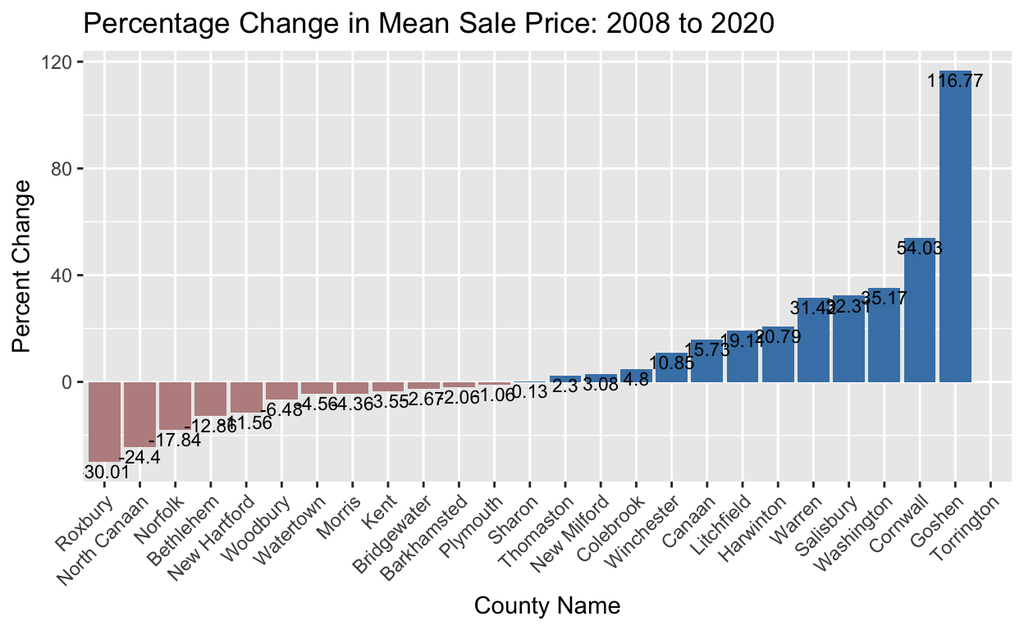

```r
L_combined %>%
  mutate(Color = ifelse(L_c_mean < 0, "rosybrown","steelblue")) %>%
  ggplot(aes(x = reorder(town, +L_c_mean),
             y = L_c_mean,
             fill = Color)) +
  geom_col()+
  geom_text(aes(label = L_c_mean,
                vjust = 1.2),
                size = 3) +
  labs(title = "Percentage Change in Mean Sale Price: 2008 to 2020",
                x = "County Name",
                y = "Percent Change") +
  theme(axis.text.x = element_text(angle = 45,
                                            hjust = 1)) +
  scale_fill_identity(guide = "none")
```

```r
Litchfield %>%
  count(town)
```

```
# A tibble: 337 × 3
# Groups:   sale_year [13]
   sale_year town            n
       <dbl> <chr>       <int>
 1      2008 Barkhamsted    27
 2      2008 Bethlehem      22
 3      2008 Bridgewater    12
 4      2008 Canaan          5
 5      2008 Colebrook      18
 6      2008 Cornwall       22
 7      2008 Goshen          9
 8      2008 Harwinton      32
 9      2008 Kent           33
10      2008 Litchfield     71
# … with 327 more rows
```

## Time Series Analysis: Arima

**Create a time series object using singe family properties and weekly mean**

```r
ts_object <- connecticut %>%
  group_by(residential_type, week = lubridate::floor_date(sale_date, "week")) %>%
  summarise(mean_L = mean(sale_price)) %>%
  filter(residential_type == "Single Family")
```

**Create time series, predict future price behavior**

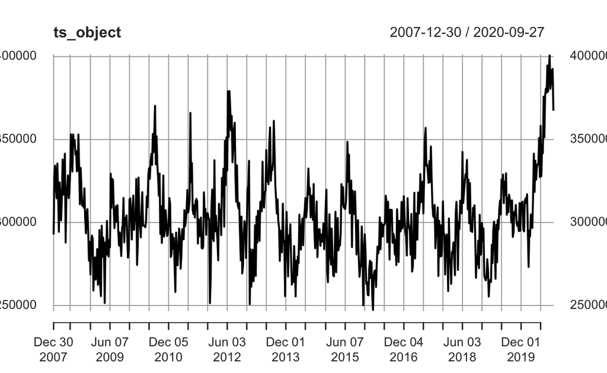

```r
ts_object <- xts(ts_object$mean_L, ts_object$week)

plot(ts_object)
```

```r
pred <- auto.arima(ts_object)

forcast1 <- forecast(pred, 10)

print(forcast1)
```

```
     Point Forecast    Lo 80    Hi 80    Lo 95    Hi 95
4663       371356.5 351916.6 390796.4 341625.8 401087.2
4670       367049.0 346515.0 387583.0 335645.0 398453.1
4677       361690.1 340159.0 383221.2 328761.2 394619.0
4684       356143.5 333425.6 378861.3 321399.5 390887.4
4691       350616.8 326593.5 374640.1 313876.3 387357.3
4698       345227.6 319872.5 370582.7 306450.4 384004.8
4705       340062.3 313421.0 366703.6 299317.9 380806.7
4712       335184.9 307350.6 363019.1 292616.1 377753.6
4719       330640.4 301734.3 359546.4 286432.4 374848.4
4726       326458.0 296613.8 356302.2 280815.3 372100.7
```

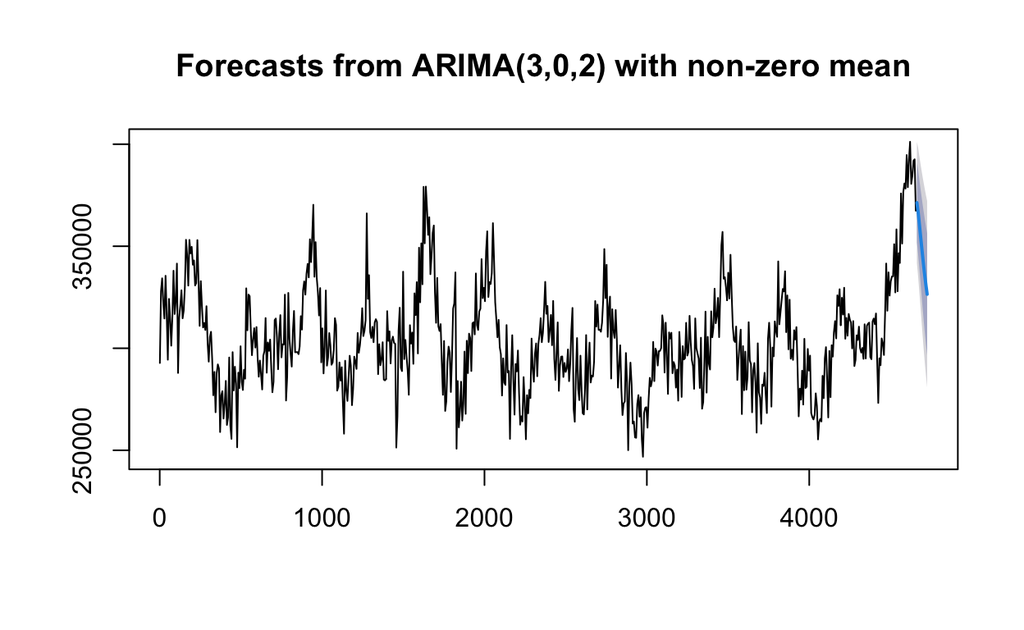

```r
plot(forcast1)
```